# Assignment Practical Machine Learning

Jimmy Hipolito

16/12/2020

## Assignment: Prediction Assignment Writeup

by: Jimmy Hipolito date: december 2020

# 1. Overview

This proyect is about of quantify how well they do a particular activity. We will use data from accelerometers on the belt, forearm, arm, and dumbell of 6 participants.

# 2. Library

```r
library(caret) #version 6.0-86
library(knitr) #version 1.30
library(rpart) #version 4.1-15
library(rattle) #version 5.4.0
library(randomForest) #version 4.6-14
```

```r
library(lattice) #version 0.20-41
library(ggplot2) #version 3.3.2
```

# 3. Datasets

The training and the testing data are available in the Course Project section of the Practical Machine Learning course. After downloading the data, it is cleared of null values and dimensions are checked.

```r
trainUrl <- "https://d396qusza40orc.cloudfront.net/predmachlearn/pml-training.csv"
testUrl  <- "https://d396qusza40orc.cloudfront.net/predmachlearn/pml-testing.csv"

#cleaning
train <- read.csv(url(trainUrl), na.strings=c("NA","#DIV/0!",""))
test <- read.csv(url(testUrl), na.strings=c("NA","#DIV/0!",""))

#checking dimension
dim(train)
```

```
## [1] 19622   160
```

```r
dim(test)
```

```
## [1]  20 160
```

# 4. Data Cleaning

In this section, the variables with missing values are eliminated, and finally the necessary variables are selected (the first 7 variables are removed, as they contain non-relevant information)

```r
train <-train[,colSums(is.na(train)) == 0]
test <-test[,colSums(is.na(test)) == 0]

train <-train[,-c(1:7)]
test <-test[,-c(1:7)]

dim(train)
```

```
## [1] 19622    53
```

```r
dim(test)
```

```
## [1] 20 53
```

# 5. Dataset Partitioning

The training dataset is partitioned in 2 sets: a Training set (70% of the data) and a Test set (30% of the data). The testing dataset, composed of 20 cases, will only be used to resolve the final quiz.

```r
# Partitions training dataset
intrain <- createDataPartition(train$classe, p=0.7, list=FALSE)
training <- train[intrain, ]
testing <- train[-intrain, ]

dim(training)
```

```
## [1] 13737    53
```

```r
dim(testing)
```

```
## [1] 5885   53
```

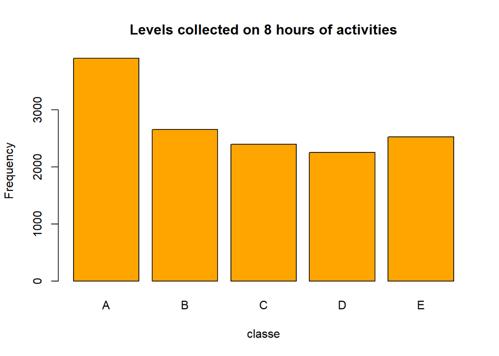

```r
barplot(table(training$classe), col="orange", main="Levels collected on 8 hours of activities", xlab="classe", ylab="Frequency")
```

# 6 Prediciton

In this section, three methods learned in the course will be applied: Decision Trees, Random Forest and Generalized Boosted Model (GBM). The model with the best Accuracy will be chosen for the final prediction with the test data.

# a. Decision Trees

```r
set.seed(33833)

# Fitting model
model_dt <- rpart(classe ~ ., data=training, method="class")
# Predicting
predict_dt <- predict(model_dt, newdata=testing, type="class")
#Testing
confusionMatrix(table(predict_dt, testing$classe))
```

```
## Confusion Matrix and Statistics
##
##
## predict_dt    A    B    C    D    E
##          A 1486  165   17   31   14
##          B   55  730   85   76   86
##          C   71  110  842  148  135
##          D   13   86   52  636   49
##          E   49   48   30   73  798
##
## Overall Statistics
##
##                Accuracy : 0.7633
##                  95% CI : (0.7522, 0.7741)
##     No Information Rate : 0.2845
##     P-Value [Acc > NIR] : < 2.2e-16
##
##                   Kappa : 0.7004
##
##  Mcnemar's Test P-Value : < 2.2e-16
##
## Statistics by Class:
##
##                      Class: A Class: B Class: C Class: D Class: E
## Sensitivity            0.8877   0.6409   0.8207   0.6598   0.7375
## Specificity            0.9461   0.9364   0.9045   0.9594   0.9584
## Pos Pred Value         0.8675   0.7074   0.6447   0.7608   0.7996
## Neg Pred Value         0.9549   0.9157   0.9598   0.9350   0.9419
## Prevalence             0.2845   0.1935   0.1743   0.1638   0.1839
## Detection Rate         0.2525   0.1240   0.1431   0.1081   0.1356
## Detection Prevalence   0.2911   0.1754   0.2219   0.1421   0.1696
## Balanced Accuracy      0.9169   0.7886   0.8626   0.8096   0.8479
```

# b. Random Forest

```r
set.seed(33833)

# Fitting model
model_rf  <- train( classe ~.,data = training,method ="rf",trControl= trainControl(method="cv",number=3))
# Predicting
predict_rf <- predict(model_rf, newdata=testing)
# Testing
confusionMatrix(table(predict_rf, testing$classe))
```

```
## Confusion Matrix and Statistics
##
##
## predict_rf    A    B    C    D    E
##          A 1674   10    0    0    0
##          B    0 1128    9    0    0
##          C    0    1 1017    9    1
##          D    0    0    0  955    4
##          E    0    0    0    0 1077
##
## Overall Statistics
##
##                Accuracy : 0.9942
##                  95% CI : (0.9919, 0.996)
##     No Information Rate : 0.2845
##     P-Value [Acc > NIR] : < 2.2e-16
##
##                   Kappa : 0.9927
##
##  Mcnemar's Test P-Value : NA
##
## Statistics by Class:
##
##                      Class: A Class: B Class: C Class: D Class: E
## Sensitivity            1.0000   0.9903   0.9912   0.9907   0.9954
## Specificity            0.9976   0.9981   0.9977   0.9992   1.0000
## Pos Pred Value         0.9941   0.9921   0.9893   0.9958   1.0000
## Neg Pred Value         1.0000   0.9977   0.9981   0.9982   0.9990
## Prevalence             0.2845   0.1935   0.1743   0.1638   0.1839
## Detection Rate         0.2845   0.1917   0.1728   0.1623   0.1830
## Detection Prevalence   0.2862   0.1932   0.1747   0.1630   0.1830
## Balanced Accuracy      0.9988   0.9942   0.9945   0.9949   0.9977
```

# c. Generalized Boosted Model (GBM)

```r
set.seed(33833)

# Fitting model
model_gbm  <- train( classe ~.,data = training,method ="gbm",trControl= trainControl(method="repeatedcv",number=3,repeats=1),verbose=FALSE)
# Predicting
predict_gbm <- predict(model_gbm, newdata=testing)
# Testing
confusionMatrix(table(predict_gbm, testing$classe))
```

```
## Confusion Matrix and Statistics
##
##
## predict_gbm    A    B    C    D    E
##           A 1656   46    0    2    1
##           B   11 1067   23    1    8
##           C    4   25  988   27    8
##           D    2    1   14  925   14
##           E    1    0    1    9 1051
##
## Overall Statistics
##
##                Accuracy : 0.9664
##                  95% CI : (0.9614, 0.9708)
##     No Information Rate : 0.2845
##     P-Value [Acc > NIR] : < 2.2e-16
##
##                   Kappa : 0.9574
##
##  Mcnemar's Test P-Value : 2.995e-06
##
## Statistics by Class:
##
##                      Class: A Class: B Class: C Class: D Class: E
## Sensitivity            0.9892   0.9368   0.9630   0.9595   0.9713
## Specificity            0.9884   0.9909   0.9868   0.9937   0.9977
## Pos Pred Value         0.9713   0.9613   0.9392   0.9676   0.9896
## Neg Pred Value         0.9957   0.9849   0.9921   0.9921   0.9936
## Prevalence             0.2845   0.1935   0.1743   0.1638   0.1839
## Detection Rate         0.2814   0.1813   0.1679   0.1572   0.1786
## Detection Prevalence   0.2897   0.1886   0.1788   0.1624   0.1805
## Balanced Accuracy      0.9888   0.9639   0.9749   0.9766   0.9845
```

# 7. Prediction

In conclusion, the Random Forest model will be applied to predict the 20 quiz results.

```r
predict_test <- predict(model_rf, newdata=test)
predict_test
```

```
##  [1] B A B A A E D B A A B C B A E E A B B B
## Levels: A B C D E
```